# Exploring social media analytics with R

[Maria Prokofieva](https://github.com/mariaprokofieva)

02/12/2018

Social media analytics (SMA) is a powerful tool that offer wide opportunities for academics and industry professionals. SMA relates to a number of tools to collect data from digital media platforms, process it into structured insights and assist in more information-driven decision making. The tutorial introduces SMA with R.

### Topics covered during the tutorial include:

- Benefits and challenges working with social media data (textual/non-textual information, large data volume, API access)
- Structure of the social media data (e.g. user-related data, posting related data, hashtags)
- Connecting to a social media platform (e.g. authentication) and downloading data

Connecting to Twitter from R

### Resource:

- [Packages to be used - please install]

```r
> install.packages ("rtweet")
>
> install.packages("ggplot2")
> install.packages("tidytext")
> install.packages("dplyr")
> install.packages("readr")
> install.packages("stringr")
> install.packages("tidyr")
> install.packages("scales")
> install.packages("wordcloud")
> install.packages("reshape2")
```

- Reference material

[Setting up the Twitter R package for text analytics](https://www.r-bloggers.com/setting-up-the-twitter-r-package-for-text-analytics/)

[Setting API for rtweet](https://rtweet.info/articles/auth.html) ________

- R and RStudio installation

R is a free software environment for data analysis and visualisation. It runs on a variety of platforms, including Windows and MacOS. You can download R for your computer

[for Windows](https://cran.r-project.org/bin/windows/base/)

Once R is installed, please install RStudio [here](https://www.rstudio.com/products/rstudio/download/) - use RStudio Desktop Open Source License

The installation is very straightforward, but you can also have a look at these tutorials

[install R for Windows](https://www.youtube.com/watch?v=Ohnk9hcxf9M)

[install R for Mac](https://www.youtube.com/watch?v=uxuuWXU-7UQ)

### Connecting to Twitter from R

- Your App Name
- Your Consumer Key (API Key)
- Consumer Secret (API Secret)

There are two main R packaages to work with Twitter:

- [`rtweet`](https://cran.r-project.org/web/packages/rtweet/index.html)
- [`twitteR`](https://cran.r-project.org/web/packages/twitteR/README.html)

In this tutorial we will be using `rtweet`

To use this package you need to install it in R first. You do it by typing the following line

```r
> install.packages("rtweet")
```

We will also need several more packages to work with data:

```r
> install.packages("ggplot2")
> install.packages("tidytext")
> install.packages("dplyr")
> install.packages("readr")
> install.packages("stringr")
> install.packages("tidyr")
> install.packages("scales")
> install.packages("wordcloud")
> install.packages("reshape2")
```

and then load these packages

```r
> library (rtweet)
> library(ggplot2)
> library(tidytext)
> library (dplyr)
> library (readr)
> library(stringr)
> library(tidyr)
> library(scales)
> library(wordcloud)
> library(reshape2)
```

Now you are all ready to go!

To connect to Twitter you need to set up your access variables:

```r
> # whatever name you assigned to your created app
> appname <- "MariaP"
>
> ## api key (example below is not a real key)
> key <- "XXXXXXXXXX"
>
> ## api secret (example below is not a real key)
> secret <- "YYYYYYYYYY"
```

Now let’s create a token and connect!

```r
> twitter_token <- create_token(
>   app = appname,
>   consumer_key = key,
>   consumer_secret = secret)
```

`create_token` function sends a request to generate your access token. The technical part of this is explained [here](https://developer.twitter.com/en/docs/basics/authentication/overview/oauth)

We are all ready to go! Let’s search out tweets.

`search_tweet` function is fantastic. It allow you search hashtags and user timelines. It takes the folowing arguments

```r
> SydneyTweets <- search_tweets(q = "Sydney", n = 1000, lang = "en", include_rts = FALSE)
> MelbourneTweets <- search_tweets(q = "Melbourne", n = 1000, lang = "en", include_rts = FALSE)
```

- `q`: query to be searched
- `n`: number of tweets to return. The maximum is 18,000. But you will need to do this in “batches”, so need to use `retryonratelimit` argument
- `include_rts`: if set to FALSE, retweets are excluded from the results

Let’s see how frequenty tweets appear

[figure not shown]

Frequency of tweets with #sydney

```r
> ts_plot(SydneyTweets, by="days")
```

or if we want to be more fancy!

[figure not shown]

Adding some elements to the graph

```r
>   ts_plot(SydneyTweets, "mins") +
>     labs (
>       x="Date and time",
>       y="Frequency of tweets",
>       title="Time series of #Sydney tweets"
>     ) +
>     theme_dark()
```

We can get tweets from a particular Twitter account using `get_timeline`

```r
>   MelbourneCityTweets <- get_timeline("cityofmelbourne")
>   SydneyCityTweets <- get_timeline("cityofsydney")
```

Let’s visualise their frequencies

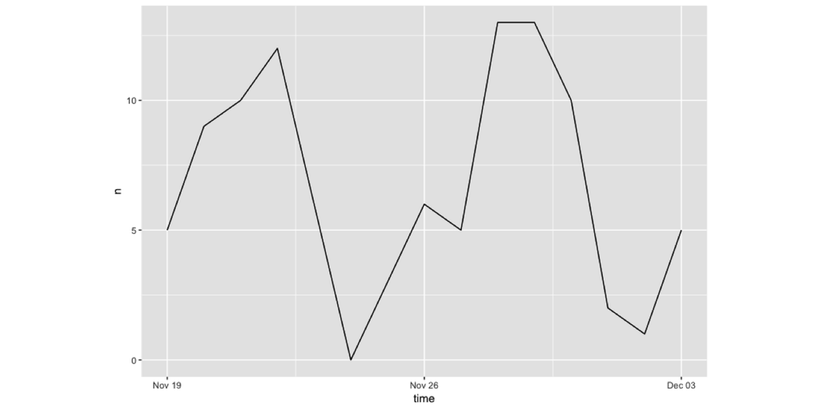

Frequencies of @CityOfMelbourne tweet, days

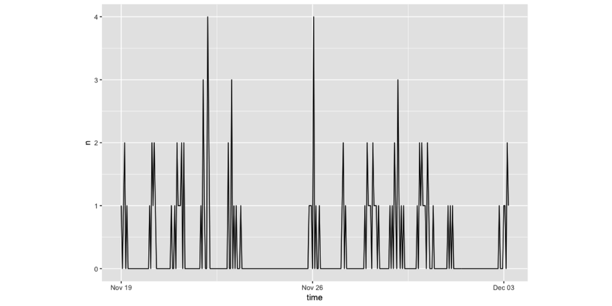

Frequencies of @CityOfMelbourne tweet, hours

```r
>   ts_plot(MelbourneCityTweets, "days")
>   ts_plot(MelbourneCityTweets, "hours")
>   ts_plot(SydneyCityTweets, "days")
>   ts_plot(SydneyCityTweets, "hours")
```

Let’s merge two datasets for hashtag tweets and add a label ‘city’

```r
>   tweets <- bind_rows(MelbourneTweets %>%
>                         mutate(city = "Melbourne"),
>                       SydneyTweets %>%
>                         mutate(city = "Sydney"))
```

Let’s count how many times each user used the hashtag for the city

```r
>   tweets<-tweets %>%
+     add_count(user_id)
> kable(tweets[5:10, 3:6])
```

[output not shown]

and let’s draw it

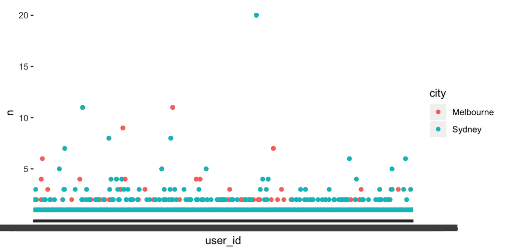

```r
>   ggplot(tweets, aes(x = user_id, y=n, color= city)) + geom_point()
```

You can also search Twitter user data using `lookup_users`:

```r
> users <- c("cityofsydney", "cityofmelbourne")
> cityTweets <- lookup_users(users)
```

```r
> kable(cityTweets[5:10, 3:6])
```

[output not shown]

Lookup friends

```r
>   city_fds <- get_friends(users)
```

Lookup followers

```r
>   city_flw <- get_followers("cityofsydney", n = 75000)
```

Lookup data on followers’ accounts

Let’s have a look at Word frequencies in tweets, but first we need to clean them to remove unwanted characters that Twitter specific, we also remove stop words, punctuation etc.

```r
> remove_reg <- "&amp;|&lt;|&gt;"
>   cityTweets_tidy <- cityTweets %>%
+     filter(!str_detect(text, "^RT")) %>%
+     mutate(text = str_remove_all(text, remove_reg)) %>%
+     unnest_tokens(word, text, token = "tweets") %>%
+     filter(!word %in% stop_words$word,
+            !word %in% str_remove_all(stop_words$word, "'"),
+            str_detect(word, "[a-z]"))
```

Calculate frequencies of words for these two accounts

```r
>   frequency <- cityTweets_tidy %>%
+     group_by(city) %>%
+     count(word, sort = TRUE) %>%
+     left_join(cityTweets_tidy %>%
+                 group_by(city) %>%
+                 summarise(total = n())) %>%
+     mutate(freq = n/total)
>   frequency
```

```
## # A tibble: 1,765 x 5
## # Groups:   city [2]
##    city      word          n total    freq
##    <chr>     <chr>     <int> <int>   <dbl>
##  1 Sydney    city         33  1475 0.0224
##  2 Sydney    sydney       28  1475 0.0190
##  3 Melbourne city         16  1198 0.0134
##  4 Melbourne melbourne    13  1198 0.0109
##  5 Sydney    ref          12  1475 0.00814
##  6 Melbourne christmas    11  1198 0.00918
##  7 Sydney    christmas    11  1475 0.00746
##  8 Sydney    nsw          11  1475 0.00746
##  9 Sydney    team         11  1475 0.00746
## 10 Sydney    transport    10  1475 0.00678
## # ... with 1,755 more rows
```

Let’s make the table more readable

```r
>   frequency <- frequency %>%
+     select(city, word, freq) %>%
+     spread(city, freq) %>%
+     arrange(Melbourne, Sydney)
>
>   frequency
```

```
## # A tibble: 1,593 x 3
##    word       Melbourne   Sydney
##    <chr>          <dbl>    <dbl>
##  1 access      0.000835 0.000678
##  2 activated   0.000835 0.000678
##  3 australian  0.000835 0.000678
##  4 awards      0.000835 0.000678
##  5 beautiful   0.000835 0.000678
##  6 beginning   0.000835 0.000678
##  7 begins      0.000835 0.000678
##  8 bins        0.000835 0.000678
##  9 care        0.000835 0.000678
## 10 catch       0.000835 0.000678
## # ... with 1,583 more rows
```

Let’s visualise frequencies

Words near the line are used with about equal frequencies by Melbourne and Sydney, while words far away from the line are used much more by one account compared to the other.

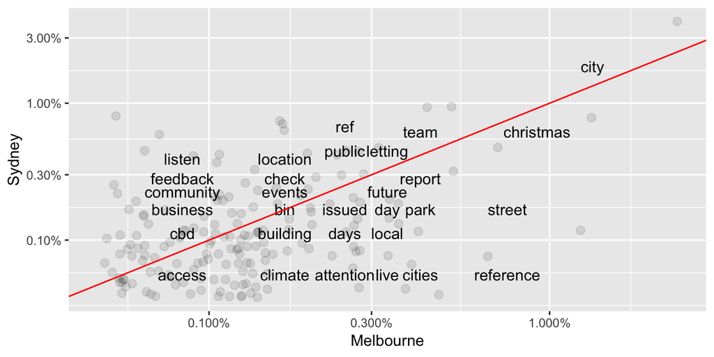

```r
>   ggplot(frequency, aes(Melbourne, Sydney)) +
+     geom_jitter(alpha = 0.1, size = 2.5, width = 0.25, height = 0.25) +
+     geom_text(aes(label = word), check_overlap = TRUE, vjust = 1.5) +
+     scale_x_log10(labels = percent_format()) +
+     scale_y_log10(labels = percent_format()) +
+     geom_abline(color = "red")
```

Now let’s do wordclouds for a merged dataset

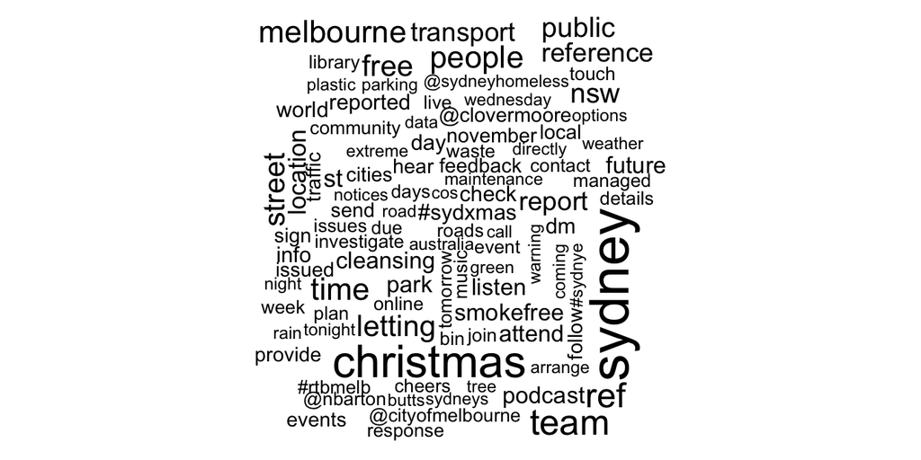

```r
>   cityTweets_tidy %>%
+     count(word, sort = TRUE)  %>%
+     with(wordcloud(word, n, max.words = 100))
```

and for @cityofSydney

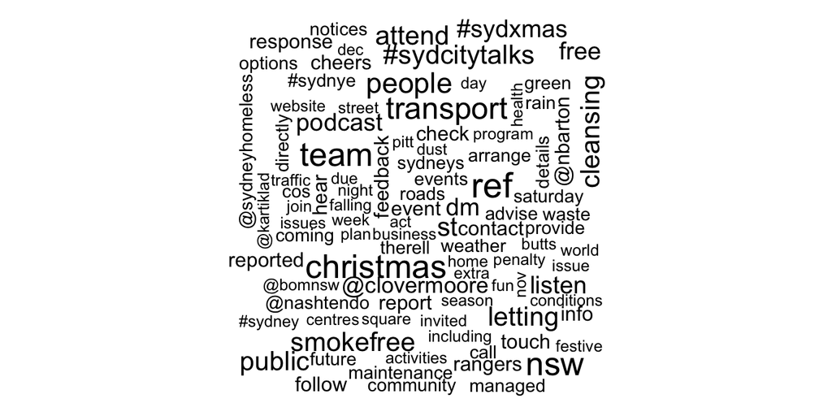

```r
>   cityTweets_tidy %>%
+     filter(city=="Sydney")%>%
+     count(word, sort = TRUE)  %>%
+     with(wordcloud(word, n, max.words = 100))
```

Let’s get the wordcloud for positive and negative words

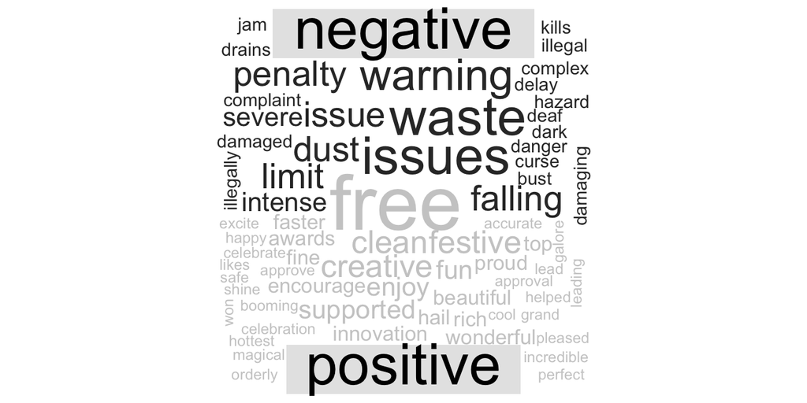

```r
>   cityTweets_tidy %>%
+     inner_join(get_sentiments("bing")) %>%
+     count(word, sentiment, sort = TRUE) %>%
+     acast(word ~ sentiment, value.var = "n", fill = 0) %>%
+     comparison.cloud(colors = c("gray20", "gray80"),
+                      max.words = 100)
```